# Social 2022 H1 Data Aggregation

Advanced Analytics Team

2022-08-05

# BigQuery and R Studio Live Training

## Big Query

- All projects for Advanced Analytics will be found in this schema: https://console.cloud.google.com/welcome?project=essence-analytics-dwh
  - Clicking (Start New Query) on this link should take you to the explorer where you can search for `essence-analytics-dwh` and make sure you pin the project to your list of projects

[figure not shown]

  - Pinned Projects will show up under explorer and you should be able to view the various schema and tables associated with that project. There you can run and queries in editor. Save the views in BQ associated with that Query. Share query with other people and set a destination table for query if creating a permanent table. Be mindful of the amount of MBs the query will process! Very large queries can cost money.

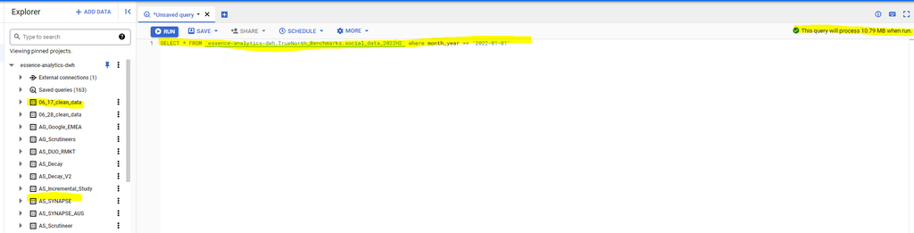

  - For our purposes we generally export the data provided by big query into a Domino Jupyter Notebook (not shown) or local R Studio Session with a BQ connection.

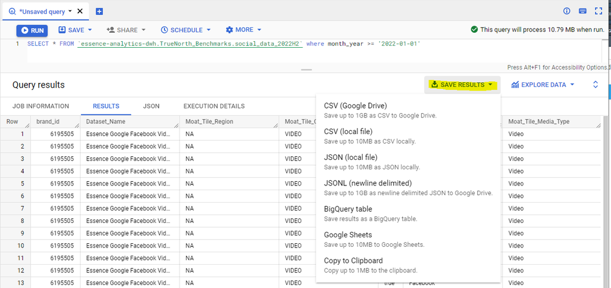

#### Exercise 1

- Try finding the table in the explorer in essence-analytics-dwh associated with the query:\ `SELECT * FROM` ``essence-analytics-dwh.TrueNorth_Benchmarks.social_data_2022H2`` `where month_year >= '2022-01-01'`
- The data associated with this table can be found in two locations
  - [Google Sheets](https://docs.google.com/spreadsheets/d/1OT7zoqbcnadQsR8ehHbvMfKn8mieWYa-dVaCOHFdhHI/edit#gid=12056137)
  - [Github CSV](https://github.com/dpatel-Essence/Brand_Report-AdHoc-Requests/blob/main/Social%20Query%202022%20Results%20Updated%20-%20Social%20Results%202022.csv)

## Google Sheets

- Some features that are used a decent amount include sharing a doc, making a copy of things you only have read access to (such as templates), downloading to CSV/Excel/JSON, version control.

[figure not shown]

- Other features in the data tab that are often used are creating filters, projecting parts of a sheet, data cleanup, text to columns, and connecting a Gsheet back to BigQuery.

[figure not shown]

- Lastly, adding comments or insering links to a cell

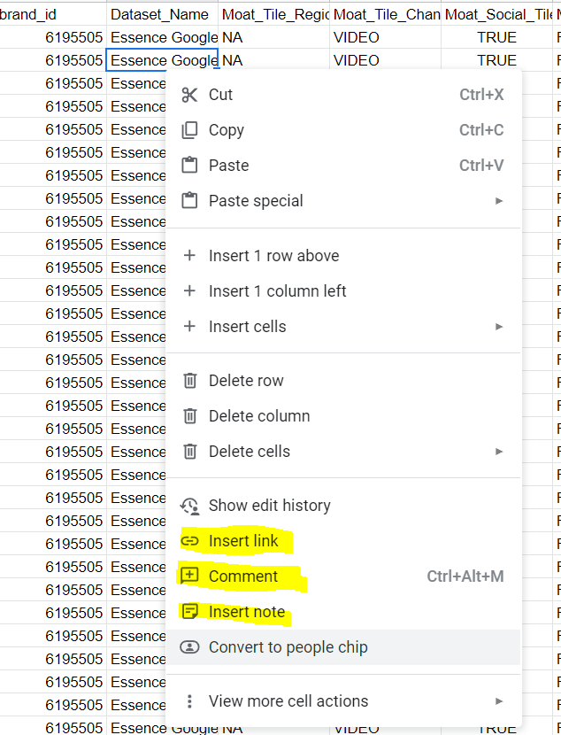

## RStudio

### Projects instead of using Working Directory! - Setting Up Projects

- In 2022, [many practitioners (including the person who created R4DS)](https://r4ds.had.co.nz/workflow-projects.html) of R prefer the use of projects instead of setting a working directory. A project will house all data, scripts, notebooks, and output associated with that workflow. Projects will appear in the top right, and you can switch them at whim and it will load the workspace you last used for that project including notebooks and your global environment.
- This goes hand in hand with creating a Github folder associated with the project. Lets see how a project can be created in a few minutes.

#### Step 1. Setting Up a blank Github Folder locally

- The easiest way to do this is set up a blank repository first locally and then associate a project with the repository instead of doing everything through R.

[figure not shown]

#### Step 2. Create a new project associated with that blank repository (file -> new project)

[figure not shown]

#### Step 3. Choose Existing Directory not Version Control Directory

The feature works, it just seems to be a more roundabout way if your goal is to have version control.

[figure not shown]

#### Step 4. Choose Location of where local repository is located and click create project

[figure not shown]

### Exercise 2 - Create your own project related to this training with or without version control.

Use can download the CSV of the Social data or create your own folders!

### Commiting Project Updates in 3 Easy Ways

1. Through Github Desktop - after publishing to your Essence account. This is the easiest but has no terminal associated.

[figure not shown]

2. Through VSCode - if you open a project folder that is linked to a Github Repo, VScode will automatically link it through version control. The terminal is also available for git operations.

[figure not shown]

3. Through RStudio (not recommended for your Essence account) - Git Tab. Sometimes your local Rstudio may not have the correct permissions to stage, commit, and push changes, but you can view history and use the terminal for git operations.

[figure not shown]

### [YAML - click for documentation](https://bookdown.org/yihui/rmarkdown/html-document.html)

The YAML is your configuration options. It appears before any code or markdown is written. Indentation is important. Additional documentation is provided if you click the header link but you can use something similar to what I use for my notebooks:

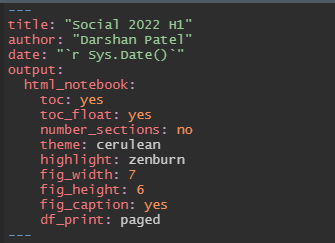

The most important thing is to make sure the output is `html_notebook` otherwise you can’t see any previews and R won’t make html file for you.

### [Writing things in markdown and common options for code Chunks](https://www.rstudio.com/wp-content/uploads/2015/02/rmarkdown-cheatsheet.pdf)

Refer to this for making headers etc…, in markdown format or just use the visual markdown editor! There are some HTML elements that can also be incorporated and CSS styling.

## Configuring the Output of Setup Chunk

CTRL+ALT+I or typing ```{r}``` creates new R code chunks. These can be named and have different ways to include options. By default the first code chunk is your setup code (can be changed in options). Typically this has all the options you want to include globally and can include your libraries.

*Press CTRL + Enter to run the following code in your RMD*

```r
#note: normally include = FALSE for this
knitr::opts_chunk$set(echo = TRUE) #all code chunks by default will be shown
options(knitr.table.format = "html") #table format
options(digits=5) #set digits in numbers
options(scipen = 100) #digits show before using scientific notation
knitr::opts_chunk$set(tidy.opts=list(width.cutoff=80), tidy=TRUE)
#install.packages("pacman")
library(pacman) #for quick load/install of packages
p_load(
  dplyr, readr, tidyverse,forcats,purrr,lubridate, # reading in data
  janitor, sqldf,googlesheets4, # additional tools for dealing with data
  skimr,
  rqdatatable, #
  splitstackshape,stringr, #string related libraries
  kableExtra, ggplot2, plotly,echarts4r,ggpubr,scales,RColorBrewer,ggthemes, #for visualization of data
  reticulate #for using python
)
```

## Loading Data

### Method 1: Directly from the Google Sheet

Note this is much slower than importing from a CSV but useful when working with a lot of google sheets.

You can specify range, sheet, and other options. [CheatSheet Here](https://github.com/rstudio/cheatsheets/blob/main/data-import.pdf)

```r
Social_2022_raw_data = googlesheets4::read_sheet(
  "https://docs.google.com/spreadsheets/d/1OT7zoqbcnadQsR8ehHbvMfKn8mieWYa-dVaCOHFdhHI/edit#gid=12056137"
  , sheet = 'Social Results 2022' , range = 'A1:K98329')
```

### Method 2: A CSV from your project folder

If you have your project set up correctly, it should be auto complete when you begin your quotes (press tab) for exporting data in your code chunk.

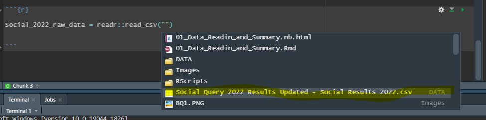

```r
Social_2022_raw_data <- readr::read_csv("DATA/Social Query 2022 Results Updated - Social Results 2022.csv")
```

### Summary of the Data

There are several functions and libraries that can be used to summarize the data quickly.

```r
summary(Social_2022_raw_data)
```

```
    brand_id       Dataset_Name       Moat_Tile_Region   Moat_Tile_Channel  Moat_Social_Tile
 Min.   :2029758   Length:98328       Length:98328       Length:98328       Mode:logical
 1st Qu.:6150812   Class :character   Class :character   Class :character   TRUE:98328
 Median :6195425   Mode  :character   Mode  :character   Mode  :character
 Mean   :5918101
 3rd Qu.:6195433
 Max.   :6244404

 Moat_Tile_Platform Moat_Tile_Media_Type  month_year        valid_and_viewable valid_and_viewable_gm
 Length:98328       Length:98328         Length:98328       Min.   :       0   Min.   :       0
 Class :character   Class :character     Class :character   1st Qu.:     244   1st Qu.:    1790
 Mode  :character   Mode  :character     Mode  :character   Median :    3518   Median :   13076
                                                            Mean   :   88423   Mean   :  145299
                                                            3rd Qu.:   27964   3rd Qu.:   69287
                                                            Max.   :41406272   Max.   :84149870
                                                                               NA's   :40035
 impressions_analyzed
 Min.   :       1
 1st Qu.:     782
 Median :   11325
 Mean   :  291280
 3rd Qu.:   90628
 Max.   :96915016
```

```r
dplyr::glimpse(Social_2022_raw_data)
```

```
Rows: 98,328
Columns: 11
$ brand_id              <dbl> 6195505, 6195505, 6195505, 6195505, 6195505, 6195505, 6195505, 6195505, ~
$ Dataset_Name          <chr> "Essence Google Facebook Video NA", "Essence Google Facebook Video NA", ~
$ Moat_Tile_Region      <chr> NA, NA, NA, NA, NA, NA, NA, NA, NA, NA, NA, NA, NA, NA, NA, NA, NA, NA, ~
$ Moat_Tile_Channel     <chr> "VIDEO", "VIDEO", "VIDEO", "VIDEO", "VIDEO", "VIDEO", "VIDEO", "VIDEO", ~
$ Moat_Social_Tile      <lgl> TRUE, TRUE, TRUE, TRUE, TRUE, TRUE, TRUE, TRUE, TRUE, TRUE, TRUE, TRUE, ~
$ Moat_Tile_Platform    <chr> "Facebook", "Facebook", "Facebook", "Facebook", "Facebook", "Facebook", ~
$ Moat_Tile_Media_Type  <chr> "Video", "Video", "Video", "Video", "Video", "Video", "Video", "Video", ~
$ month_year            <chr> "4/1/2022", "4/1/2022", "4/1/2022", "4/1/2022", "4/1/2022", "4/1/2022", ~
$ valid_and_viewable    <dbl> 5096, 103217, 24418, 21033, 5621, 29199, 3283, 33791, 2524234, 204459, 1~
$ valid_and_viewable_gm <dbl> NA, NA, NA, NA, NA, NA, NA, NA, NA, NA, NA, NA, NA, NA, NA, NA, NA, NA, ~
$ impressions_analyzed  <dbl> 30343, 627311, 226206, 197509, 46001, 214920, 25263, 258856, 22985797, 1~
```

```r
str(Social_2022_raw_data)
```

```
spec_tbl_df [98,328 x 11] (S3: spec_tbl_df/tbl_df/tbl/data.frame)
 $ brand_id             : num [1:98328] 6195505 6195505 6195505 6195505 6195505 ...
 $ Dataset_Name         : chr [1:98328] "Essence Google Facebook Video NA" "Essence Google Facebook Video NA" "Essence Google Facebook Video NA" "Essence Google Facebook Video NA" ...
 $ Moat_Tile_Region     : chr [1:98328] NA NA NA NA ...
 $ Moat_Tile_Channel    : chr [1:98328] "VIDEO" "VIDEO" "VIDEO" "VIDEO" ...
 $ Moat_Social_Tile     : logi [1:98328] TRUE TRUE TRUE TRUE TRUE TRUE ...
 $ Moat_Tile_Platform   : chr [1:98328] "Facebook" "Facebook" "Facebook" "Facebook" ...
 $ Moat_Tile_Media_Type : chr [1:98328] "Video" "Video" "Video" "Video" ...
 $ month_year           : chr [1:98328] "4/1/2022" "4/1/2022" "4/1/2022" "4/1/2022" ...
 $ valid_and_viewable   : num [1:98328] 5096 103217 24418 21033 5621 ...
 $ valid_and_viewable_gm: num [1:98328] NA NA NA NA NA NA NA NA NA NA ...
 $ impressions_analyzed : num [1:98328] 30343 627311 226206 197509 46001 ...
 - attr(*, "spec")=
  .. cols(
  ..   brand_id = col_double(),
  ..   Dataset_Name = col_character(),
  ..   Moat_Tile_Region = col_character(),
  ..   Moat_Tile_Channel = col_character(),
  ..   Moat_Social_Tile = col_logical(),
  ..   Moat_Tile_Platform = col_character(),
  ..   Moat_Tile_Media_Type = col_character(),
  ..   month_year = col_character(),
  ..   valid_and_viewable = col_double(),
  ..   valid_and_viewable_gm = col_double(),
  ..   impressions_analyzed = col_double()
  .. )
 - attr(*, "problems")=<externalptr>
```

```r
dim(Social_2022_raw_data)
```

```
[1] 98328    11
```

### Exercise 3 - What are 2 issues that you can find based on the following output

```r
skimr::skim(Social_2022_raw_data)
```

```
-- Data Summary ------------------------
                           Values
Name                       Social_2022_raw_data
Number of rows             98328
Number of columns          11
_______________________
Column type frequency:
  character                6
  logical                  1
  numeric                  4
________________________
Group variables            None

-- Variable type: character ----------------------------------------------------------------------------
# A tibble: 6 x 8
  skim_variable        n_missing complete_rate   min   max empty n_unique whitespace
* <chr>                    <int>         <dbl> <int> <int> <int>    <int>      <int>
1 Dataset_Name                 0         1        31    53     0       34          0
2 Moat_Tile_Region         18011         0.817     4     4     0        2          0
3 Moat_Tile_Channel            0         1         5     7     0        2          0
4 Moat_Tile_Platform           0         1         6     9     0        5          0
5 Moat_Tile_Media_Type         0         1         5    15     0        5          0
6 month_year                   0         1         8     8     0        6          0

-- Variable type: logical ------------------------------------------------------------------------------
# A tibble: 1 x 5
  skim_variable    n_missing complete_rate  mean count
* <chr>                <int>         <dbl> <dbl> <chr>
1 Moat_Social_Tile         0             1     1 TRU: 98328

-- Variable type: numeric ------------------------------------------------------------------------------
# A tibble: 4 x 11
  skim_variable         n_missing complete_rate     mean       sd      p0     p25      p50      p75
* <chr>                     <int>         <dbl>    <dbl>    <dbl>   <dbl>   <dbl>    <dbl>    <dbl>
1 brand_id                      0         1     5918101.  921804. 2029758 6150812 6195425  6195433
2 valid_and_viewable            0         1       88423.  613041.       0     244    3518.   27964.
3 valid_and_viewable_gm     40035         0.593  145299.  973454.       0    1790   13076    69287
4 impressions_analyzed          0         1      291280. 1724658.       1     782   11325    90628
      p100 hist
*    <dbl> <chr>
1  6244404 ▁▁▁▁▇
2 41406272 ▇▁▁▁▁
3 84149870 ▇▁▁▁▁
4 96915016 ▇▁▁▁▁
```

### Piping Data

One very common technique in R is using a data pipe to make temporary data frames and do multiple operations without saving the objects to our global environment. This keeps the environment small, our rdata will also be small.  
There are 2 ways:

- `%>%` (requires the `dplyr` package to be loaded CTRL + SHIFT + M hotkey)
- `|>` (native to base R)

A pipe uses the previous data source to fill in any function arguments

```r
Social_2022_raw_data %>%
  head()
```

| brand_id | Dataset_Name | Moat_Tile_Region | Moat_Tile_Channel | Moat_Social_Tile | Moat_Tile_Platform | Moat_Tile_Media_Type | month_year | valid_and_viewable | valid_and_viewable_gm | impressions_analyzed |
| --- | --- | --- | --- | --- | --- | --- | --- | --- | --- | --- |
| 6195505 | Essence Google Facebook Video NA | NA | VIDEO | TRUE | Facebook | Video | 4/1/2022 | 5096 | NA | 30343 |
| 6195505 | Essence Google Facebook Video NA | NA | VIDEO | TRUE | Facebook | Video | 4/1/2022 | 103217 | NA | 627311 |
| 6195505 | Essence Google Facebook Video NA | NA | VIDEO | TRUE | Facebook | Video | 4/1/2022 | 24418 | NA | 226206 |
| 6195505 | Essence Google Facebook Video NA | NA | VIDEO | TRUE | Facebook | Video | 4/1/2022 | 21033 | NA | 197509 |
| 6195505 | Essence Google Facebook Video NA | NA | VIDEO | TRUE | Facebook | Video | 4/1/2022 | 5621 | NA | 46001 |
| 6195505 | Essence Google Facebook Video NA | NA | VIDEO | TRUE | Facebook | Video | 4/1/2022 | 29199 | NA | 214920 |

### Initial Issues from data from data read-in

1. Data for dates is read in as character instead of date. The `Lubridate` library has options to fix this.

```r
Social_2022_raw_data %>%
  dplyr::mutate( #mutate creates new variables
    date_fixed = lubridate::mdy(month_year) #converts date - month - year character to date format
  ) %>%
  select(date_fixed)
```

| date_fixed |
| --- |
| 2022-04-01 |
| 2022-04-01 |
| 2022-04-01 |
| 2022-04-01 |
| 2022-04-01 |
| 2022-04-01 |
| 2022-04-01 |
| 2022-04-01 |
| 2022-04-01 |
| 2022-04-01 |

[output cut: 990 more lines]

2. NA region is read in as missing instead of as NA. Readr can be used to prevent this, but several other variables are using NA for missing so we will modify ipso facto.

```r
Social_2022_raw_data %>%
  dplyr::mutate( #mutate creates new variables
    Moat_Tile_Region_fixed = case_when(
      !is.na(Moat_Tile_Region)  ~ Moat_Tile_Region,
      TRUE ~ 'NA'
    )  #replace_na is also an option
  )
```

| brand_id | Dataset_Name | Moat_Tile_Region | Moat_Tile_Channel | Moat_Social_Tile | Moat_Tile_Platform | Moat_Tile_Media_Type | month_year | valid_and_viewable | valid_and_viewable_gm | impressions_analyzed | Moat_Tile_Region_fixed |
| --- | --- | --- | --- | --- | --- | --- | --- | --- | --- | --- | --- |
| 6195505 | Essence Google Facebook Video NA | NA | VIDEO | TRUE | Facebook | Video | 4/1/2022 | 5096 | NA | 30343 | NA |
| 6195505 | Essence Google Facebook Video NA | NA | VIDEO | TRUE | Facebook | Video | 4/1/2022 | 103217 | NA | 627311 | NA |
| 6195505 | Essence Google Facebook Video NA | NA | VIDEO | TRUE | Facebook | Video | 4/1/2022 | 24418 | NA | 226206 | NA |
| 6195505 | Essence Google Facebook Video NA | NA | VIDEO | TRUE | Facebook | Video | 4/1/2022 | 21033 | NA | 197509 | NA |
| 6195505 | Essence Google Facebook Video NA | NA | VIDEO | TRUE | Facebook | Video | 4/1/2022 | 5621 | NA | 46001 | NA |
| 6195505 | Essence Google Facebook Video NA | NA | VIDEO | TRUE | Facebook | Video | 4/1/2022 | 29199 | NA | 214920 | NA |
| 6195505 | Essence Google Facebook Video NA | NA | VIDEO | TRUE | Facebook | Video | 4/1/2022 | 3283 | NA | 25263 | NA |
| 6195505 | Essence Google Facebook Video NA | NA | VIDEO | TRUE | Facebook | Video | 4/1/2022 | 33791 | NA | 258856 | NA |
| 6195505 | Essence Google Facebook Video NA | NA | VIDEO | TRUE | Facebook | Video | 4/1/2022 | 2524234 | NA | 22985797 | NA |
| 6195505 | Essence Google Facebook Video NA | NA | VIDEO | TRUE | Facebook | Video | 4/1/2022 | 204459 | NA | 1651560 | NA |

[output cut: 990 more lines]

### Creating New Dataset

Assigning both changes to a new dataset, cleaning names of dataset using `janitor::clean_names()`, and only keeping variables of interest, Additionally Created a variable for Quarter.

```r
Social_2022_processed_data <-
  Social_2022_raw_data %>%
    dplyr::mutate( #mutate creates new variables
      moat_tile_region_fixed = dplyr::case_when(
        !is.na(Moat_Tile_Region)  ~ Moat_Tile_Region,
        TRUE ~ 'NA'
      ),
      date_fixed = lubridate::mdy(month_year),
      quarter_fixed = lubridate::quarter(date_fixed)
    ) %>%
    janitor::clean_names() %>%
    dplyr::select(
      moat_tile_region_fixed, date_fixed, quarter_fixed, moat_tile_channel, moat_tile_platform, moat_tile_media_type, valid_and_viewable, impressions_analyzed
  )

Social_2022_processed_data %>%
  skimr::skim() %>%
  as.data.frame() # optional if automating checks
```

|  | skim_type | skim_variable | n_missing | complete_rate | character.min | character.max | character.empty | character.n_unique | character.whitespace | Date.min | Date.max | Date.median | Date.n_unique | numeric.mean | numeric.sd | numeric.p0 | numeric.p25 | numeric.p50 | numeric.p75 | numeric.p100 | numeric.hist |
| --- | --- | --- | --- | --- | --- | --- | --- | --- | --- | --- | --- | --- | --- | --- | --- | --- | --- | --- | --- | --- | --- |
| 1 | character | moat_tile_region_fixed | 0 | 1 | 2 | 4 | 0 | 3 | 0 |  |  |  | NA | NA | NA | NA | NA | NA | NA | NA | NA |
| 2 | character | moat_tile_channel | 0 | 1 | 5 | 7 | 0 | 2 | 0 |  |  |  | NA | NA | NA | NA | NA | NA | NA | NA | NA |
| 3 | character | moat_tile_platform | 0 | 1 | 6 | 9 | 0 | 5 | 0 |  |  |  | NA | NA | NA | NA | NA | NA | NA | NA | NA |
| 4 | character | moat_tile_media_type | 0 | 1 | 5 | 15 | 0 | 5 | 0 |  |  |  | NA | NA | NA | NA | NA | NA | NA | NA | NA |
| 5 | Date | date_fixed | 0 | 1 | NA | NA | NA | NA | NA | 2022-01-01 | 2022-06-01 | 2022-03-01 | 6 | NA | NA | NA | NA | NA | NA | NA | NA |
| 6 | numeric | quarter_fixed | 0 | 1 | NA | NA | NA | NA | NA |  |  |  | NA | 1.401 | 0.49011 | 1 | 1 | 1.0 | 2 | 2 |  |
| 7 | numeric | valid_and_viewable | 0 | 1 | NA | NA | NA | NA | NA |  |  |  | NA | 88423.368 | 613040.89834 | 0 | 244 | 3518.5 | 27964 | 41406272 |  |
| 8 | numeric | impressions_analyzed | 0 | 1 | NA | NA | NA | NA | NA |  |  |  | NA | 291279.626 | 1724658.48447 | 1 | 782 | 11325.0 | 90628 | 96915016 |  |

### Checks on the data - using summarize function and group by

Valid Impressions should be less than Total Impressions. There are a few cases where this principle doesn’t hold.

```r
Social_2022_processed_data %>%
  dplyr::mutate(
    flag_impression = dplyr::case_when(
      valid_and_viewable > impressions_analyzed ~ 1,
      TRUE ~ -1
    )
  ) %>%
  dplyr::group_by(flag_impression) %>%
  dplyr::summarise(
    count = sum(flag_impression) #summarize can use custom aggregation functions that you create!
  ) %>% ungroup() #useful if using the dataset again - not necessary here
```

| flag_impression | count |
| --- | --- |
| -1 | -97437 |
| 1 | 891 |

All the cases are for twitter which we aren’t interested in

```r
Social_2022_processed_data %>%
  dplyr::mutate(
    flag_impression = dplyr::case_when(
      valid_and_viewable > impressions_analyzed ~ 1,
      TRUE ~ 0
    )
  ) %>%
  dplyr::filter (flag_impression == 1 & moat_tile_platform != 'Twitter') # '&' is used as a 'and' operator while '|' is used as an 'or' operator
```

| moat_tile_region_fixed | date_fixed | quarter_fixed | moat_tile_channel | moat_tile_platform | moat_tile_media_type | valid_and_viewable | impressions_analyzed | flag_impression |
| --- | --- | --- | --- | --- | --- | --- | --- | --- |

Timing of the data should only be in 2022 (we can see this from skimmed data, but to double check)

```r
Social_2022_processed_data %>%
  dplyr::summarize(
    Min_date = min(date_fixed),
    Max_date = max(date_fixed)
  )
```

| Min_date | Max_date |
| --- | --- |
| 2022-01-01 | 2022-06-01 |

```r
Social_2022_processed_data %>%
  dplyr::select(moat_tile_channel) %>%
  unique()
```

| moat_tile_channel |
| --- |
| VIDEO |
| DISPLAY |

There are also base functions which can be used for this purpose although they don’t produce data frames

```r
unique(Social_2022_processed_data$moat_tile_channel)
```

```
[1] "VIDEO"   "DISPLAY"
```

```r
unique(Social_2022_processed_data[["moat_tile_platform"]]) #useful for creating functions when column name is specified.
```

```
[1] "Facebook"  "Snapchat"  "Instagram" "TikTok"    "Twitter"
```

```r
unique(Social_2022_processed_data$moat_tile_channel) %>% as.data.frame()
```

| . |
| --- |
| VIDEO |
| DISPLAY |

This is the dplyr way to get all unique combinations and counts

```r
Social_2022_processed_data %>%
  dplyr::group_by(moat_tile_platform, moat_tile_channel) %>%
  dplyr::summarise(
    distinct_combos = dplyr::n_distinct(moat_tile_platform, moat_tile_channel),
    distinct_combos2 = n()
  )
```

| moat_tile_platform | moat_tile_channel | distinct_combos | distinct_combos2 |
| --- | --- | --- | --- |
| Facebook | DISPLAY | 1 | 36529 |
| Facebook | VIDEO | 1 | 17647 |
| Instagram | DISPLAY | 1 | 21764 |
| Instagram | VIDEO | 1 | 15496 |
| Snapchat | DISPLAY | 1 | 476 |
| Snapchat | VIDEO | 1 | 1425 |
| TikTok | VIDEO | 1 | 433 |
| Twitter | VIDEO | 1 | 4558 |

### Creating Summary Group_by Pivotable Table

One thing to note is that there are many ways to apply group_bys, selects, filters, summaries, mutates across all variable types (for example all characters or dates or starts with a prefix). A minus will also remove a variable from a select. Specific column names can also be selected with one_of.

```r
Social_2022_summarized_data <-
  Social_2022_processed_data %>%
  group_by(
    dplyr::across(where(lubridate::is.Date)),
    quarter_fixed,
    dplyr::across(dplyr::starts_with("moat"))
  ) %>%
  dplyr::ungroup(moat_tile_media_type) %>%
  dplyr::select(-moat_tile_media_type) %>%
  summarize(
    valid_and_viewable_imp = sum(valid_and_viewable),
    impressions = sum(impressions_analyzed),
    valid_and_viewable_rate = sum(valid_and_viewable) / sum(impressions_analyzed)
  ) %>%
  dplyr::ungroup() %>%
  dplyr::arrange_all()
```

The `kableExtra` package provides a nice way to look at html tables

```r
Social_2022_summarized_data %>%
  dplyr::select(-quarter_fixed,-valid_and_viewable_imp,-impressions) %>%
  dplyr::slice_head(n = 10) %>%
  kableExtra::kbl() %>%
 kableExtra::kable_material(c("striped", "hover","condensed","responsive"),full_width = F,fixed_thead = T)
```

| date_fixed | moat_tile_region_fixed | moat_tile_channel | moat_tile_platform | valid_and_viewable_rate |
| --- | --- | --- | --- | --- |
| 2022-01-01 | APAC | DISPLAY | Facebook | 0.46598 |
| 2022-01-01 | APAC | DISPLAY | Instagram | 0.37822 |
| 2022-01-01 | APAC | DISPLAY | Snapchat | 1.00000 |
| 2022-01-01 | APAC | VIDEO | Facebook | 0.43467 |
| 2022-01-01 | APAC | VIDEO | Instagram | 0.06997 |
| 2022-01-01 | APAC | VIDEO | Twitter | 0.32117 |
| 2022-01-01 | EMEA | DISPLAY | Facebook | 0.52638 |
| 2022-01-01 | EMEA | DISPLAY | Instagram | 0.40139 |
| 2022-01-01 | EMEA | VIDEO | Facebook | 0.21194 |
| 2022-01-01 | EMEA | VIDEO | Instagram | 0.07243 |

### Exercise 4 - Group this data set further

Get Valid/Viewable rate at the quarter, channel, platform level. Filter platform so twitter is excluded.

```r
### Answer goes here , your table should have 4 columns minimum!
```

### Outputting Data as a Googlesheet

It will be similar to reading a sheet. Be careful as this will over-ride the existing sheet. Good Practice is to leave commented out after running.

```r
#WRITING SHEETS WILL BE COMMENTED OUT UNLESS REFRESH IS NECESSARY
#write_sheet(Social_2022_summarized_data, ss = 'https://docs.google.com/spreadsheets/d/1OT7zoqbcnadQsR8ehHbvMfKn8mieWYa-dVaCOHFdhHI/edit#gid=12056137',
#           sheet = 'Aggregated Data')
```

### Other tips

- Dplyr Cheatsheet (help -> cheatsheets in menu), joins, distinct, counts, slicing, renaming, bind_rows as an alternative to rbind,
- [Janitor Functions](https://cran.r-project.org/web/packages/janitor/vignettes/janitor.html) - more than just clean names()
- Tabsets, Pseudo-HTML, better looking tables and other formatting options
- SQL in R - Sqldf package
- Alt for multiple commenting out or un-commenting selections. Hotkey for commenting all code.
- Styling code (addins -> style selection)
- Easier to read code chunk options
- Using the Visual Markdown Editor and outline mode
- Tab Autocomplete
- Factors, ordering/leveling factors, usefulness in graphing - forcats package
- Melting and reshaping data - making data wider and longer - pivot_wider, pivot_longer, and melt from reshape2